# Introduction to Dimensional Reduction in R - UseR!22 (Section II)

Isabella Bicalho Frazeto

2022-06-19

# Section 1

In this section we will explore the dataset for PCA and ICA and define a little bit more how to to use tidymodels.

## Importing libraries

```r
#import data and tidy models, section 1
library(tidymodels)
```

```r
tidymodels_prefer()
library(bestNormalize)
library(cowplot)
library(ggforce)
library(forcats)
library(tidytext)
```

## Dataset

Let’s inspect the dataset

```r
library(beans)
skimr::skim(beans)
```

Data summary

| Name | beans |
| --- | --- |
| Number of rows | 13611 |
| Number of columns | 17 |
| _______________________ |  |
| Column type frequency: |  |
| factor | 1 |
| numeric | 16 |
| ________________________ |  |
| Group variables | None |

**Variable type: factor**

| skim_variable | n_missing | complete_rate | ordered | n_unique | top_counts |
| --- | --- | --- | --- | --- | --- |
| class | 0 | 1 | FALSE | 7 | der: 3546, sir: 2636, sek: 2027, hor: 1928 |

**Variable type: numeric**

| skim_variable | n_missing | complete_rate | mean | sd | p0 | p25 | p50 | p75 | p100 | hist |
| --- | --- | --- | --- | --- | --- | --- | --- | --- | --- | --- |
| area | 0 | 1 | 53048.28 | 29324.10 | 20420.00 | 36328.00 | 44652.00 | 61332.00 | 254616.00 | ▇▂▁▁▁ |
| perimeter | 0 | 1 | 855.28 | 214.29 | 524.74 | 703.52 | 794.94 | 977.21 | 1985.37 | ▇▆▁▁▁ |
| major_axis_length | 0 | 1 | 320.14 | 85.69 | 183.60 | 253.30 | 296.88 | 376.50 | 738.86 | ▇▆▂▁▁ |
| minor_axis_length | 0 | 1 | 202.27 | 44.97 | 122.51 | 175.85 | 192.43 | 217.03 | 460.20 | ▇▇▁▁▁ |
| aspect_ratio | 0 | 1 | 1.58 | 0.25 | 1.02 | 1.43 | 1.55 | 1.71 | 2.43 | ▂▇▅▂▁ |
| eccentricity | 0 | 1 | 0.75 | 0.09 | 0.22 | 0.72 | 0.76 | 0.81 | 0.91 | ▁▁▂▇▇ |
| convex_area | 0 | 1 | 53768.20 | 29774.92 | 20684.00 | 36714.50 | 45178.00 | 62294.00 | 263261.00 | ▇▂▁▁▁ |
| equiv_diameter | 0 | 1 | 253.06 | 59.18 | 161.24 | 215.07 | 238.44 | 279.45 | 569.37 | ▇▆▁▁▁ |
| extent | 0 | 1 | 0.75 | 0.05 | 0.56 | 0.72 | 0.76 | 0.79 | 0.87 | ▁▁▅▇▂ |
| solidity | 0 | 1 | 0.99 | 0.00 | 0.92 | 0.99 | 0.99 | 0.99 | 0.99 | ▁▁▁▁▇ |
| roundness | 0 | 1 | 0.87 | 0.06 | 0.49 | 0.83 | 0.88 | 0.92 | 0.99 | ▁▁▂▇▇ |
| compactness | 0 | 1 | 0.80 | 0.06 | 0.64 | 0.76 | 0.80 | 0.83 | 0.99 | ▂▅▇▂▁ |
| shape_factor_1 | 0 | 1 | 0.01 | 0.00 | 0.00 | 0.01 | 0.01 | 0.01 | 0.01 | ▁▃▇▃▁ |
| shape_factor_2 | 0 | 1 | 0.00 | 0.00 | 0.00 | 0.00 | 0.00 | 0.00 | 0.00 | ▇▇▇▃▁ |
| shape_factor_3 | 0 | 1 | 0.64 | 0.10 | 0.41 | 0.58 | 0.64 | 0.70 | 0.97 | ▂▇▇▃▁ |
| shape_factor_4 | 0 | 1 | 1.00 | 0.00 | 0.95 | 0.99 | 1.00 | 1.00 | 1.00 | ▁▁▁▁▇ |

```r
colnames(beans)
```

```
##  [1] "area"              "perimeter"         "major_axis_length"
##  [4] "minor_axis_length" "aspect_ratio"      "eccentricity"
##  [7] "convex_area"       "equiv_diameter"    "extent"
## [10] "solidity"          "roundness"         "compactness"
## [13] "shape_factor_1"    "shape_factor_2"    "shape_factor_3"
## [16] "shape_factor_4"    "class"
```

Taking a closer look at area:

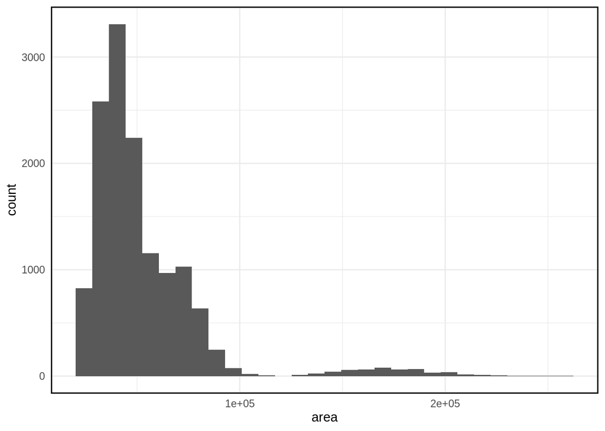

```r
beans %>%
  ggplot(aes(x = area)) +
  geom_histogram() +
  theme_minimal() +
  panel_border(color = "black")
```

Would log-scaling make a difference?

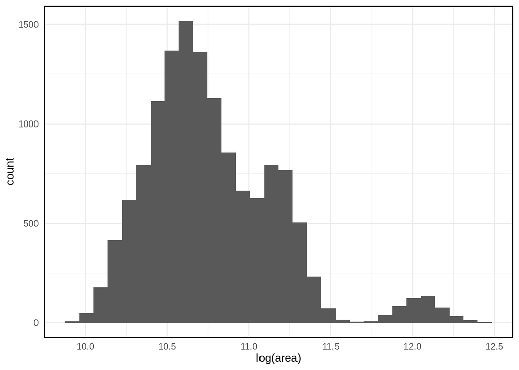

```r
beans %>%
  ggplot(aes(x = log(area))) +
  geom_histogram() +
  theme_minimal() +
  panel_border(color = "black")
```

## Tidy models

```r
set.seed(126)
beans_split <- initial_split(beans, prop = 0.80)
beans_train <- training(beans_split)
beans_test  <-  testing(beans_split)
```

### Recipes

A step-by-step description of how you process your data prior to the analysis

```r
recipe_rf <- recipe(class ~ ., data = beans_train)
```

### What is our model?

```r
rf_model <- rand_forest(
            mode = "classification",
            engine = "ranger"
            )
```

### Workflow

```r
rf_wk <- workflow() %>%
          add_recipe(recipe_rf) %>%
          add_model(rf_model)
```

### Fitting the workflow

```r
rf_fit <- fit(rf_wk, beans_train)
```

### Where do I get my results?

```r
rf_predict <- predict(rf_fit, beans_test)
```

```r
rf_aug <- augment(rf_fit, beans_test)
```

### Metrics

```r
rf_aug %>%
  recall(truth = class, estimate = .pred_class,  estimator = "macro_weighted")
```

```
## # A tibble: 1 × 3
##   .metric .estimator     .estimate
##   <chr>   <chr>              <dbl>
## 1 recall  macro_weighted     0.928
```

### Our preprocessing

We have seen in the previous section that we have to some preprocessing. Here, we will: 1) remove zero_variance from the data 2) do order quantile normalizing 3) center and scale the data (normalize)

```r
beans_preproc_rec <-   recipe(class ~ ., data = beans) %>%
                          step_zv(all_numeric_predictors()) %>%
                          step_orderNorm(all_numeric_predictors()) %>%
                          step_normalize(all_numeric_predictors())
```

We have a recipe, we can prepare our data.

```r
beans_rec_prepped <- prep(beans_preproc_rec,
                          verbose = TRUE)
```

```
## oper 1 step zv [training]
## oper 2 step orderNorm [training]
## oper 3 step normalize [training]
## The retained training set is ~ 1.72 Mb  in memory.
```

```r
beans_rec_prepped
```

```
## Recipe
##
## Inputs:
##
##       role #variables
##    outcome          1
##  predictor         16
##
## Training data contained 13611 data points and no missing data.
##
## Operations:
##
## Zero variance filter removed <none> [trained]
## orderNorm transformation on area, perimeter, major_axis_length, minor_... [trained]
## Centering and scaling for area, perimeter, major_axis_length, minor_axis_... [trained]
```

We can bake our recipe to get our results

```r
beans_processed <- bake(beans_rec_prepped,
                           new_data = NULL)
```

Recall the previous plot:

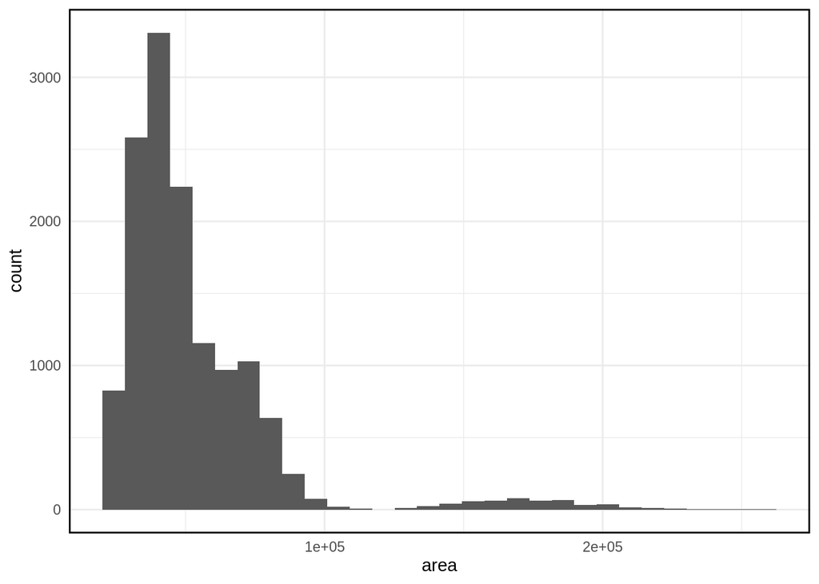

```r
beans %>%
  ggplot(aes(x = area)) +
  geom_histogram() +
  theme_minimal() +
  panel_border(color = "black")
```

Let’s now take a look at the area now

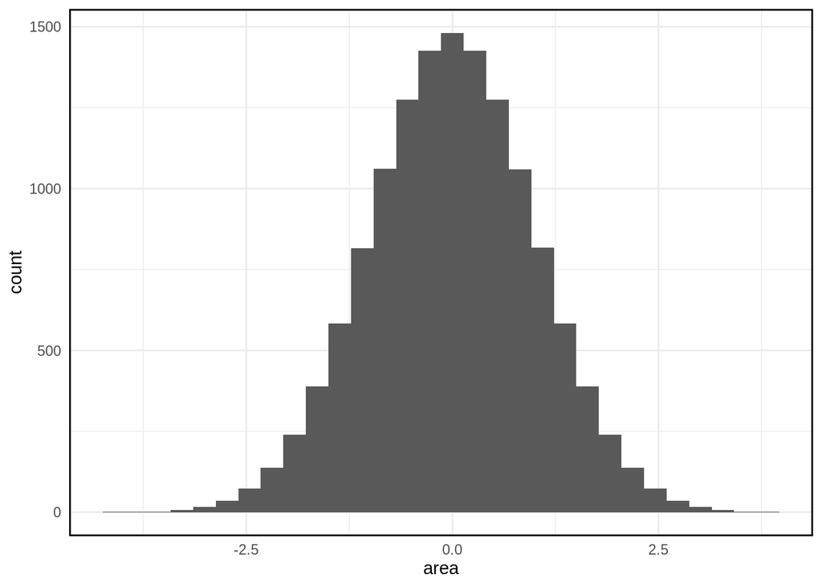

```r
beans_processed %>%
  ggplot(aes(x = area)) +
  geom_histogram() +
  theme_minimal() +
  panel_border(color = "black")
```

# Section 2

## PCA

Let’s add pca recipe to our pre-processing recipe!

```r
beans_prepped_PCA  <- beans_rec_prepped %>%
                        step_pca(all_numeric_predictors(), num_comp = 4) %>%
                        prep()
```

We will get the id from the recipe to get the variance.

```r
step_id_PCA <- beans_prepped_PCA %>%
                  tidy() %>%
                  filter(type == 'pca') %>%
                  pull(id)

beans_variance_PCA <- tidy(beans_prepped_PCA,
                           id = step_id_PCA,
                           type = "variance")
```

Please note that there are several types of variances.

## Percent Variance

How do we now what are the the PC that matter the most?

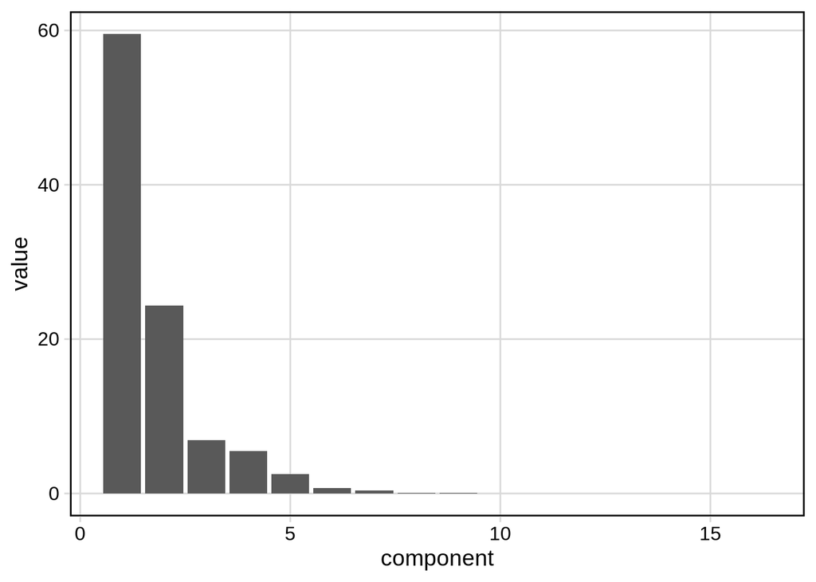

```r
beans_variance_PCA %>%
  filter(terms == "percent variance") %>%
  ggplot(aes(x = component, y = value)) +
  geom_col() +
  theme_minimal_grid() +
  panel_border(color = "black")
```

## Cumulative percent variance

Altogether, how much do they explain from our variance?

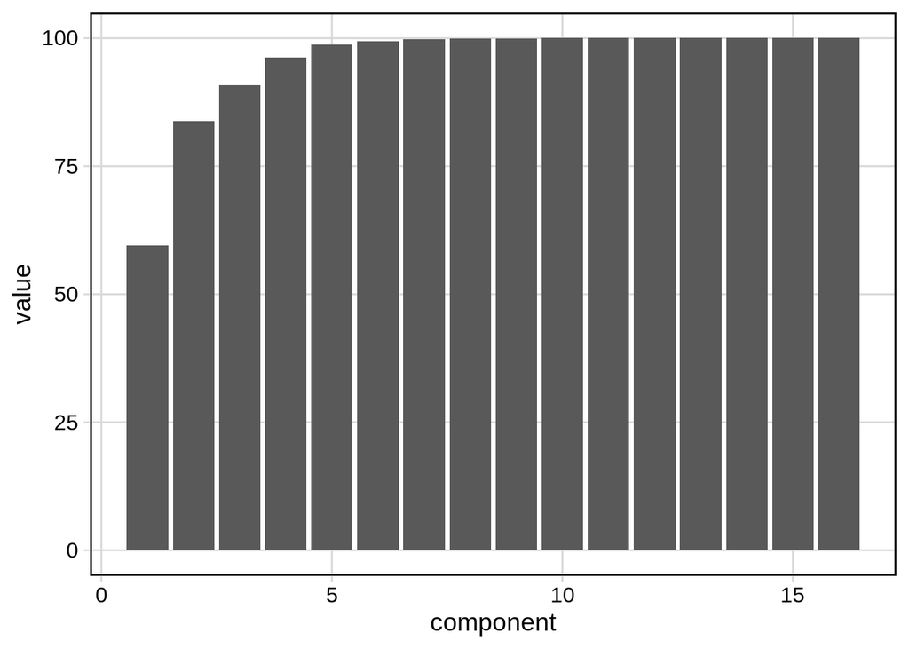

```r
beans_variance_PCA %>%
  filter(terms == "cumulative percent variance") %>%
  ggplot(aes(x = component, y = value)) +
  geom_col() +
  theme_minimal_grid() +
  panel_border(color = "black")
```

# Let’s inspect the components and their terms

```r
beans_PCA_tidied <- beans_prepped_PCA %>%
                    tidy(id = step_id_PCA)
```

How do we see how our features relate to each main component?

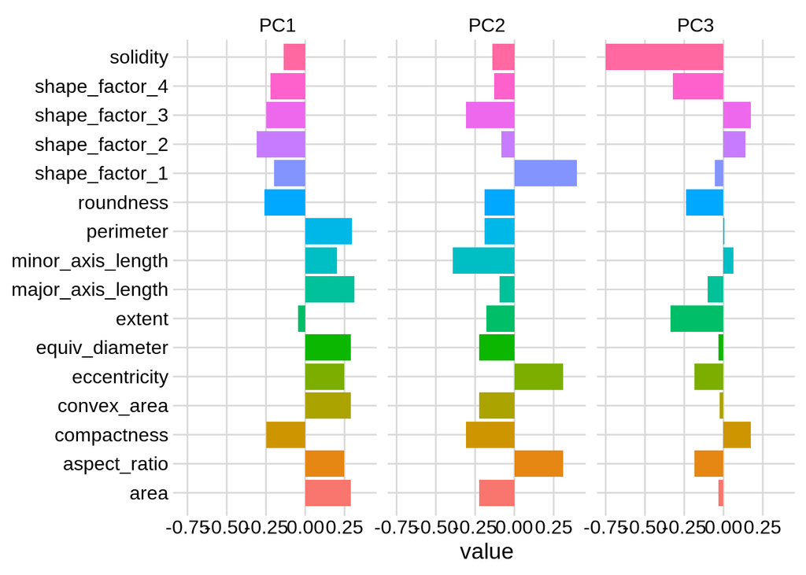

```r
beans_PCA_tidied %>%
  filter(component %in% paste0("PC", 1:3)) %>%
  mutate(component = fct_inorder(component)) %>%
  ggplot(aes(value, terms, fill = terms)) +
  geom_col(show.legend = FALSE) +
  facet_wrap(~component, nrow = 1) +
  labs(y = NULL) +
  theme_minimal_grid()
```

## Alternative way to view the same information

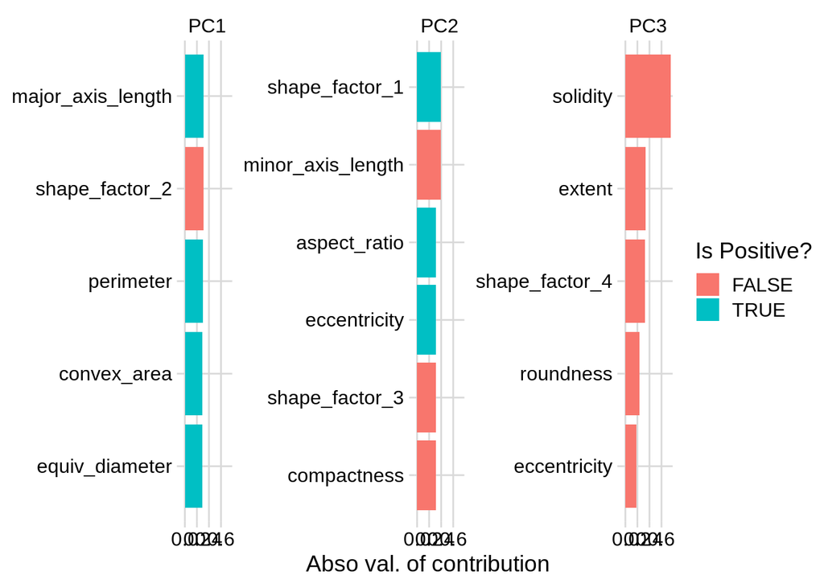

```r
beans_PCA_tidied %>%
  filter(component %in% paste0("PC", 1:3)) %>%
  mutate(
    is_positive = value > 0,
    abs_value = abs(value)
  ) %>%
  group_by(component) %>%
  slice_max(abs_value, n = 5) %>%
  ungroup() %>%
  mutate(terms = reorder_within(terms, abs(value), component)) %>%
  ggplot(aes(abs(value), terms, fill = value > 0)) +
  geom_col() +
  facet_wrap(~component, nrow = 1, scales = "free_y") +
  scale_y_reordered() +
  labs(
    x = "Abso val. of contribution",
    y = NULL, fill = "Is Positive?"
  ) +
  theme_minimal_grid()
```

## Let’s bake our recipe!

```r
beans_baked_PCA <- bake(beans_prepped_PCA, new_data =  NULL)
beans_baked_PCA
```

```
## # A tibble: 13,611 × 5
##    class   PC1    PC2    PC3      PC4
##    <fct> <dbl>  <dbl>  <dbl>    <dbl>
##  1 seker -6.13 -0.695  0.877  0.0754
##  2 seker -6.79 -2.08   2.89  -0.737
##  3 seker -5.81 -0.867  0.367  0.00721
##  4 seker -5.11 -1.01   3.45  -1.43
##  5 seker -8.40 -3.95   0.984  0.470
##  6 seker -6.06 -1.59   0.632  0.190
##  7 seker -5.51 -1.51   2.52  -0.0500
##  8 seker -6.02 -1.68   0.931 -0.0121
##  9 seker -5.92 -1.66   1.10   0.0539
## 10 seker -5.82 -1.51  -0.265  0.0873
## # … with 13,601 more rows
```

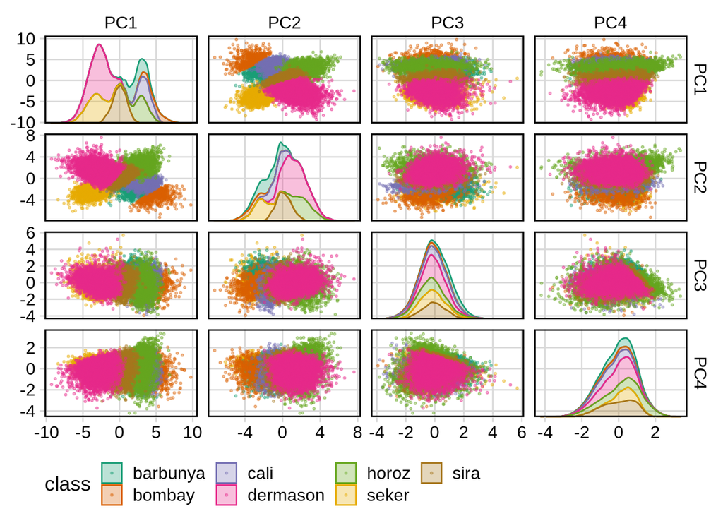

```r
beans_baked_PCA %>%
  ggplot(aes(x = .panel_x, y = .panel_y, color = class, fill = class)) +
  geom_point(alpha = 0.4, size = 0.5) +
  geom_autodensity(alpha = .3) +
  facet_matrix(vars(-class), layer.diag = 2) +
  scale_color_brewer(palette = "Dark2") +
  scale_fill_brewer(palette = "Dark2") +
  theme_minimal_grid() +
  panel_border(color = "black") +
  theme(legend.position = "bottom")
```

## Zooming in

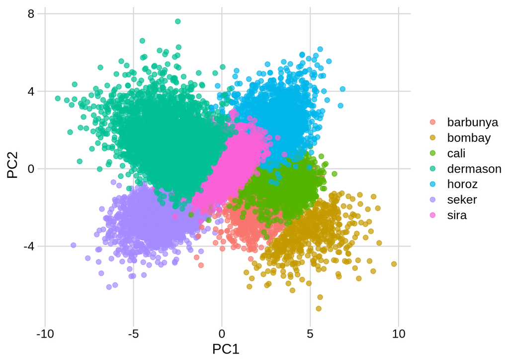

```r
beans_baked_PCA %>%
  ggplot(aes(PC1, PC2, label = class)) +
  geom_point(aes(color = class), alpha = 0.7, size = 2) +
  labs(color = NULL) +
  theme_minimal_grid()
```

## ICA

We will do the same for the ICA: 1) Create the recipe 2) Prep the recipe 3) Bake the recipe

```r
beans_rec_ICA <- beans_rec_prepped %>%
                      step_ica(all_numeric_predictors(), num_comp = 5)

beans_prepped_ICA <- beans_rec_ICA %>% prep()

beans_baked_ICA <- bake(beans_prepped_ICA, new_data = NULL)
```

## Looking at our baked results

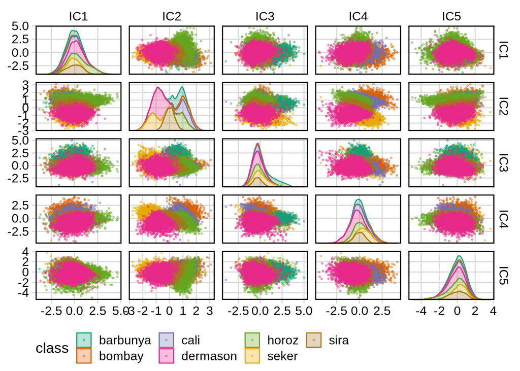

```r
beans_baked_ICA %>%
  ggplot(aes(x = .panel_x, y = .panel_y, color = class, fill = class)) +
  geom_point(alpha = 0.4, size = 0.5) +
  geom_autodensity(alpha = .3) +
  facet_matrix(vars(-class), layer.diag = 2) +
  scale_color_brewer(palette = "Dark2") +
  scale_fill_brewer(palette = "Dark2") +
  theme_minimal_grid() +
  panel_border(color = "black") +
  theme(legend.position = "bottom")
```

## Similarly, we can inspect the best looking one

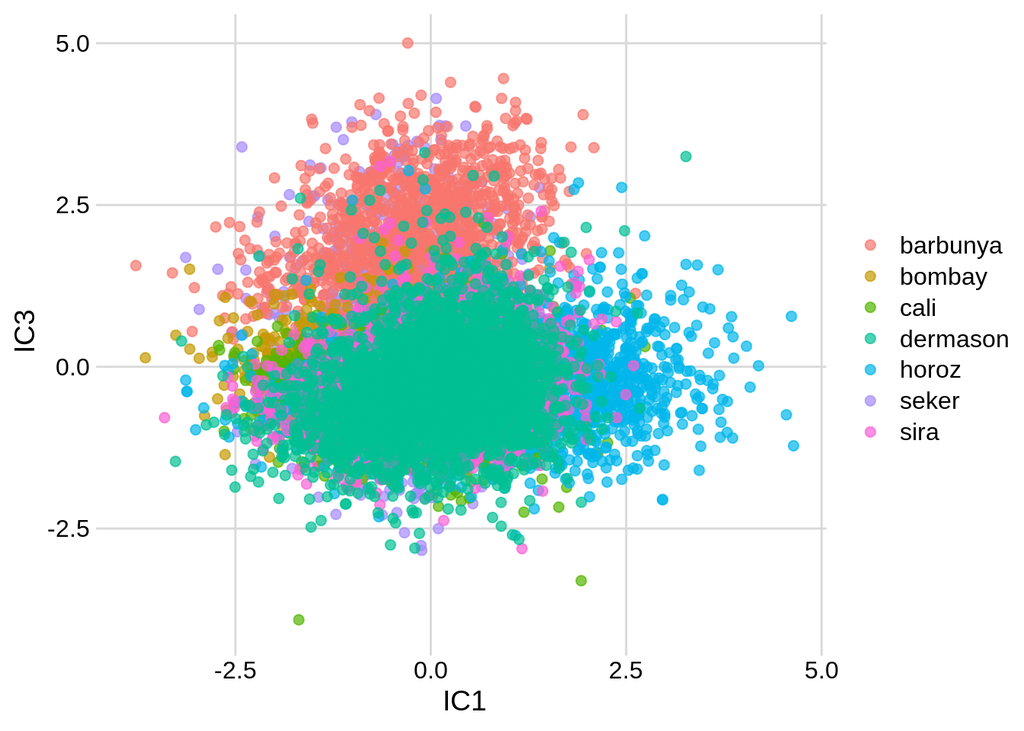

```r
beans_baked_ICA %>%
  ggplot(aes(IC1, IC3, label = class)) +
  geom_point(aes(color = class), alpha = 0.7, size = 2) +
  labs(color = NULL) +
  theme_minimal_grid()
```

## Checking how much each feature contributes to each component

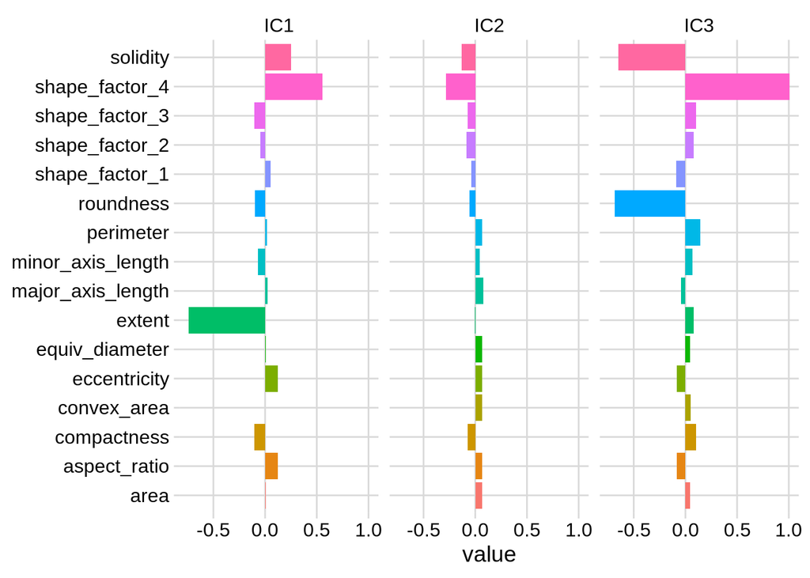

```r
step_id_ICA <- beans_prepped_ICA %>%
  tidy() %>%
  filter(type == 'ica') %>%
  pull(id)

beans_ICA_tidied <- beans_prepped_ICA %>%
                    tidy(id = step_id_ICA)

beans_ICA_tidied %>%
  filter(component %in% paste0("IC", (1:3))) %>%
  mutate(component = fct_inorder(component)) %>%
  ggplot(aes(value, terms, fill = terms)) +
  geom_col(show.legend = FALSE) +
  facet_wrap(~component, nrow = 1) +
  labs(y = NULL) +
  theme_minimal_grid()
```